# Final Project-Address

Jack Kucera, Tanner Meighan, Adam Rafique

2025-05-16

## Backround

We decided to explore the addresses of US’s roads. Specifically, the suffix of those addresses. We first needed access to the addresses in a form we could use, which the Census Bureau had on their website. There were two ways we could go about this, we could write our code to scrape the Census Bureau or we could use a free package we discovered, tigris. Of these options, we chose tigris. Tigris had many advantages to writing our own code, the biggest advantage was that tigris had built in functions to extract the exact data we needed in a format that we could easily use.

We used the tigris functions roads(), counties(), and states() throughout our project. roads() scraped the Census Bureau for road data and geometry based of state FIPS, county FIPS, and year, counties() scraped for county data and geometry based on state and year, and states() scraped for state data and geometry based on year. An important thing to note is that these functions gave geometry which made mapping the data much easier and, therefore, we did not have to mix-and-match different packages to map our subsequent data. Nonetheless, sometimes the geometry was a nuceince but there were ways around that. Overall, tigris was a huge help, very convenient, and a time saver.

## Project Parts

After we discovered tigris, we moved on to our first part of the project, mapping all of US’s counties.

### Part 1: Mapping US Counties

Before we continue, a few things to note. In the project description, the link to the Census Bureau was to addresses in 2023. Therefore, we used 2023 data instead of the more recent 2024 data. All map graphs have a more detailed .png file in the [GitHub repository](https://github.com/TuckerLive12/STAT_345_S25_FinalProject) (or in our submission on CANVAS). Now, let us continue.

Using tirgis, it was trivial to map the US counties. We just had to use the counties() function to get the geometry and map it using ggplot and sf packages.

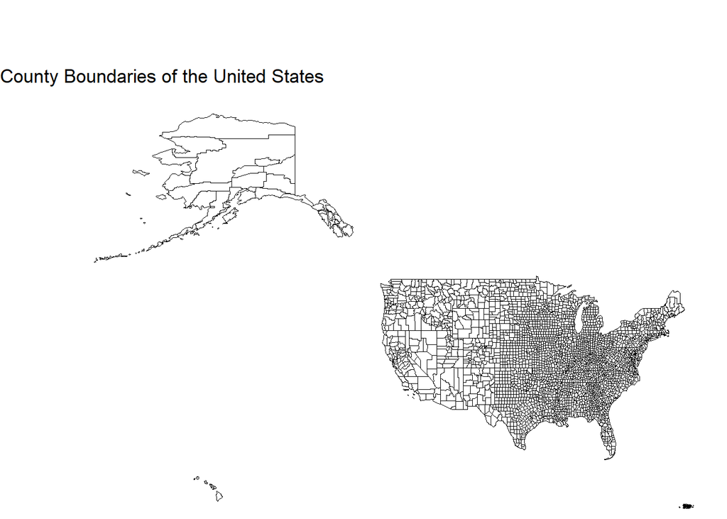

```r
# Scraping for county data and geometry
counties <- counties(cb = TRUE, resolution = "20m", year = 2023, progress_bar = FALSE)

# Plotting the US counties
county_borders <- ggplot(data = counties) +
  geom_sf(fill = "white", color = "black", size = 0.1) +
  theme_minimal() +
  labs(title = "County Boundaries of the United States") +
  theme(
    axis.text = element_blank(),
    axis.ticks = element_blank(),
    panel.grid = element_blank(),
    plot.margin = margin(l = 0, r = -33, t = 0, b = -2, unit = "cm")
  )

#ggsave("us_county_map.png", plot = county_borders, width = 32, height = 20, dpi = 600)
# Printing the map
print(county_borders)
```

Done! Next, we need to fill in the map with some data. However, before we do that, we to get useable road data.

### Part 2: Getting Useable Road Data

Of all the steps, this was the most time consuming, both in writing and running code. Nevertheless, we’ll explain how we did it. We decided to split this task into two parts: scraping and summarizing. We would first scrape all the data we thought we would need and then summarize it afterwards. While we could have done it at once, it was easier for splitting the work load and, more importantly, it was safer. Scraping the data took a *long* time and any changes that need to be made to the summarization could have set us back 10s of hours of scraping. So, we splited the task.

Now let us learn how we scraped the data. As mentioned before, we used the tigris functions roads(), counties(), and states() for scraping data. Nevertheless, we did not need the states() function for getting the addresses. How we used roads() and counties() is a little more interesting.

We decided to use a nested for-loop (although there are better ways as discussed later in the Hindsight section). We would first get all the needed county FIPS for a state from counties(), then in another for-loop we would use those FIPS in roads() to scrape a county’s roads and reiteratively add them to a data frame until we had all of that state’s road addresses in one data frame. We would then write that data frame into a .csv file to be used later during the summarization process. we would then go to the next state and the process would repeat. We did this for all 50 states.

Overall, the code took about 18 hours to run and we ended up with over 700 MB of data. There are a few important specifics to go over. Remember how I said that roads() also gave geometry? Well, that geometry took *a lot* of memory and was completely useless, so whenever we scraped the county’s roads, we would always first remove the geometry before merging the data with the rest of the state’s counties. Also, for some reason, the function we used for merging data frames (bind_rows()) could not be used with NULL. So we first had to initialize a data frame using the same code as in the loop, and then start the loop. Lastly, the state FIPS numbers are not 1-50, they are 1-56, of which there are 5 empty FIPS numbers and 1 (FIPS 11) which correspond to the District of Columbia. In order for there not to be an error in counties() when looping, we created our own data frame containing states FIPS as well as a file path per state for easy of writing the .csv file. All of the scraping can be further explored [here](https://github.com/TuckerLive12/STAT_345_S25_FinalProject/blob/main/Data_Scraping_and_Database/Data%20Scraping.R) (or in our submission on CANVAS). As for the .csv files, those can be further explored [here](https://github.com/TuckerLive12/STAT_345_S25_FinalProject/blob/main/Data_Scraping_and_Database/).

Before we move on to summarizing, we first need to understand what was in the .csv files. The .csv file (one per state) contained 7 data points per address/road, of which only 3 ended up being useful, the full name of the road (FULLNAME), the county FIPS (COUNTYFP), and the state FIPS (STATE_ID and later changed to STATEFP for joining). Here is a look at the Alabama .csv file using glimpse().

```r
# Reading in data
example_data <- read_csv("./Data_Scraping_and_Database/Alabama_Roads_2023.csv", col_types = "ccccccd")

# Glimpse into data
glimpse(example_data)
```

```
## Rows: 368,675
## Columns: 7
## $ LINEARID <chr> "1103672784948", "1103677525952", "110585093547", "1105850935…
## $ FULLNAME <chr> "McGee Rd Exn", "Buena Vis Lp", "Alt Rte Route County Road 40…
## $ RTTYP    <chr> "M", "M", "O", "O", "O", "O", "O", "O", "O", "M", "M", "M", "…
## $ MTFCC    <chr> "S1400", "S1400", "S1400", "S1400", "S1400", "S1400", "S1400"…
## $ COUNTYFP <chr> "001", "001", "001", "001", "001", "001", "001", "001", "001"…
## $ STATE_ID <chr> "1", "1", "1", "1", "1", "1", "1", "1", "1", "1", "1", "1", "…
## $ YEAR     <dbl> 2023, 2023, 2023, 2023, 2023, 2023, 2023, 2023, 2023, 2023, 2…
```

Now that we know what’s in the .csv files, we can start summarizing. First, we needed a way to get the most common suffix in a county. To do this, we decided to count how many roads have that suffix in a county. To do this we first confirmed that FULLNAME is not null, extracted the suffix (SUFFIX) from the addresses full name (FULLNAME), confirmed there is a suffix, then grouped by county FIPS and counted the total of that suffix. Since we wanted all this data in one data frame, just like extracting county roads and combining them from earlier, we had to initialize a data frame to merge with the rest of the states summarized data. All of which can be further explored [here](https://github.com/TuckerLive12/STAT_345_S25_FinalProject/blob/main/Final%20Project-Address.Rmd) (or in our submission on CANVAS).

One might have noted that we have data frame full of suffix count by county, but not the most common suffix by county. That will be addressed next in Mapping and Graphing.

### Part 3: Mapping and Graphing

We are almost done. Where was I? Right, how to get the most common suffix by county. Well, first we group by state FIPS (STATE_ID/STATEFP) and county FIPS (COUNTYFP), then we take the highest count in each group. Now we have the most common suffix by county. But, before we start mapping the most common suffix by county we need to remove some suffixes where that suffix was only the most common suffix in a few counties. More specifically, we removed any suffix with less than 5 counties as this would make the graph easier to read. Otherwise, the color gradient would be to slow to distinguish different suffixes on the map.

Now that we have done that, we can finally get to mapping the most common road suffix by county. As always, all code for the maps and graph can be found [here](https://github.com/TuckerLive12/STAT_345_S25_FinalProject/blob/main/Final%20Project-Address.Rmd) (or in our submission on CANVAS).

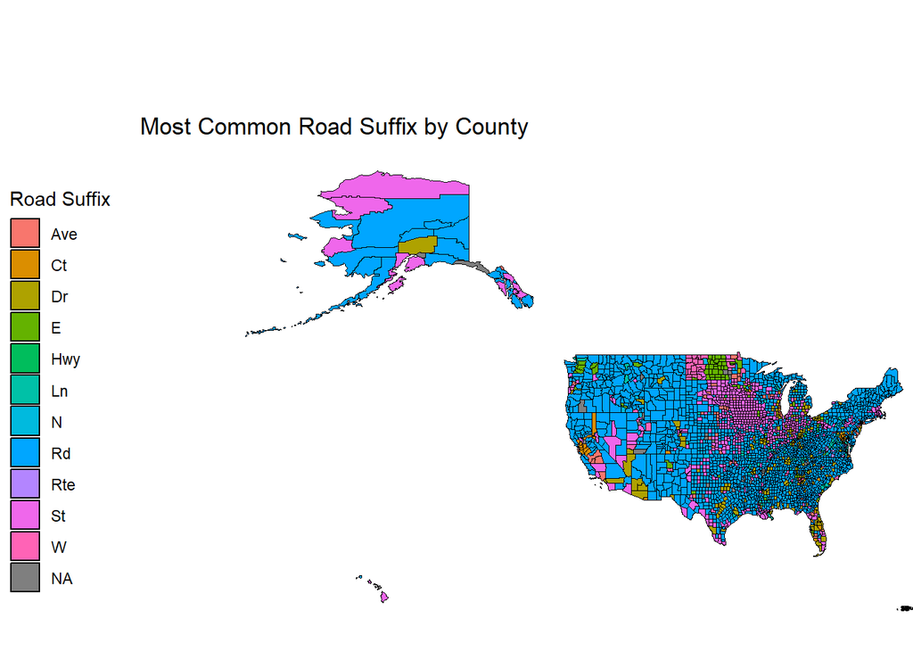

```
## # A tibble: 11 × 2
## # Groups:   SUFFIX [11]
##    SUFFIX Count_of_Most_Common_Suffix_by_County
##    <chr>                                  <int>
##  1 Rd                                      1937
##  2 St                                       614
##  3 Dr                                       215
##  4 Ln                                        88
##  5 E                                         74
##  6 Ave                                       64
##  7 W                                         49
##  8 Ct                                        39
##  9 N                                         17
## 10 Hwy                                        8
## 11 Rte                                        8
```

Its pretty interesting. As you can see, Rd is by far the most common suffix by county. You can still see some St’s and Dr’s, However after that, it becomes hard to make out a noticeable difference.

How about we look at most common suffix by state?

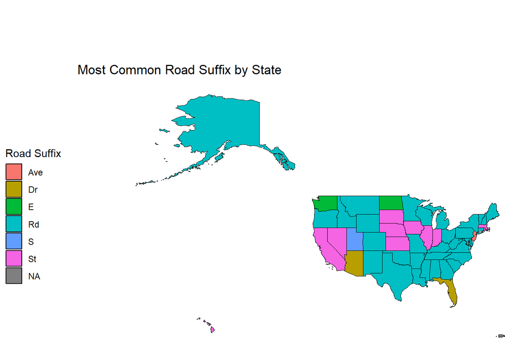

```
## # A tibble: 6 × 2
## # Groups:   SUFFIX [6]
##   SUFFIX Count_of_Most_Common_Suffix_by_State
##   <chr>                                 <int>
## 1 Rd                                       33
## 2 St                                       11
## 3 Dr                                        2
## 4 E                                         2
## 5 Ave                                       1
## 6 S                                         1
```

As you can see, Rd is by far the most common suffix by state as well. You can still see some St’s, however Dr’s have dropped off to only 2 out of 50.

Since the state map does not shown us much, let us look more into the county data. Lets look at the total number of occurrences per suffix. However, since there are a lot of suffixes, lets only look at the top 50.

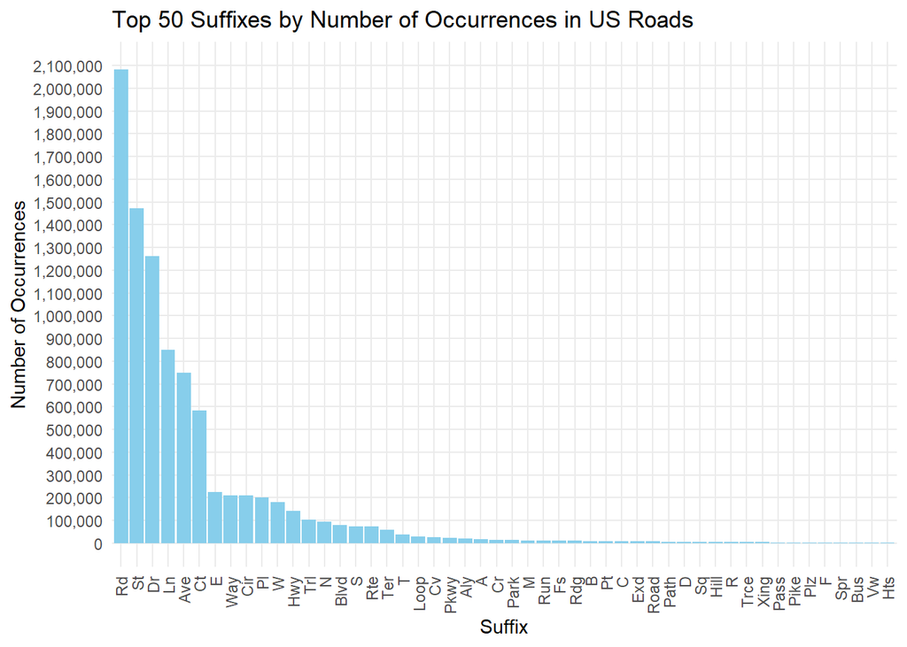

As you can see, the number of occurrences follows closely with the county and state map where Rd is ahead while St and Dr follow behind. Interesting, it seems with the number of occurrences, Rd does not dominate as it had in the maps. Probably because this is total occurrences while the maps are only the most common.

Now, let us look at the percent of occurrences in counties by suffix.

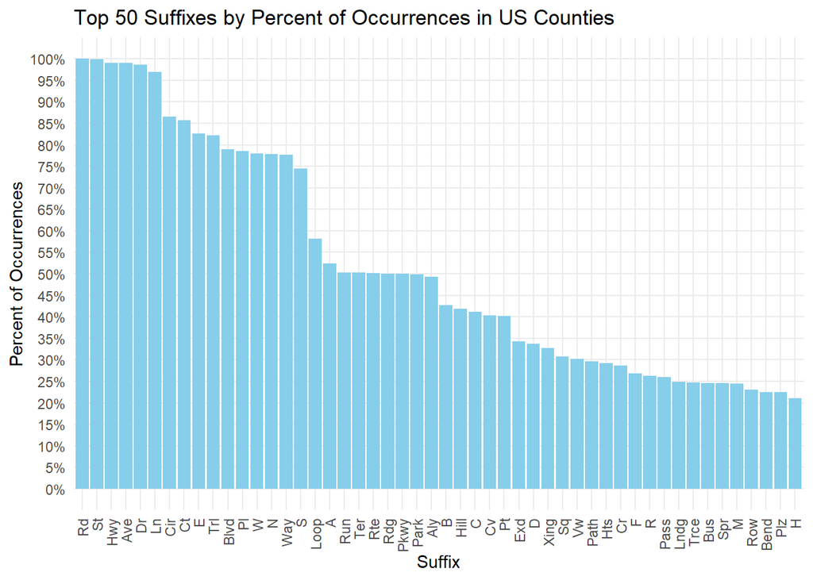

```
## # A tibble: 50 × 2
##    SUFFIX Percent_of_Occurrences_in_Counties_by_Suffix
##    <chr>                                         <int>
##  1 Rd                                             3143
##  2 St                                             3141
##  3 Hwy                                            3113
##  4 Ave                                            3112
##  5 Dr                                             3101
##  6 Ln                                             3046
##  7 Cir                                            2720
##  8 Ct                                             2692
##  9 E                                              2598
## 10 Trl                                            2584
## # ℹ 40 more rows
```

This graph is probably my favorite. It shows how much Rd dominates since the suffix Rd is in every county in the US. (3143 total counties). It also shows that Rd, St, Hwy, Ave, DR, and Ln is in at least 90% of counties. One interesting thing is that Hwy is in 90% of counties, however, only 8 counties have Hwy being the most common suffix. Makes sense since highways are everywhere by few in number.

Lastly, just for fun, we made a word cloud of the number of total occurrences of suffixes, only the top 500 though.

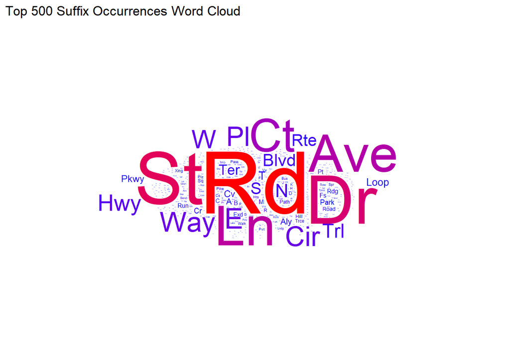

## Conclusion and Hindsight

In conclusion, we had a blast completing this project and are glad we were able compile a stellar submission. Although in hindsight there were a few things we could have done better. First, the scraping could have been a lot better. We only learned half way through scraping that roads() can accept county FIPS in vector form. If you look at out scraping code (line 78), we originally thought that in order to have COUNTYFP be in the data set we have to manually add it county by county (since roads() doesn’t scrape COUNTYFP). However, we only learned later that GEOID contains both state FIPS (STATEFP) and county FIPS (COUNTYFP). So we could have downloaded all the counties together (without needing bind_rows()), then splitting GEOID to get state FIPS (STATEFP) and county FIPS (COUNTYFP). It would have been much faster. Second, the regular expression could have been more refined. For example, we probably missed some suffixes that might not have had a capital letter as its first letter. We can easily imagine that someone miss typed or wrote a lower case r in rd. Lastly, as I’m writing this at 4 am, I realize we could have done better in our knitted file (what your likely reading). Preferably, do this not tired and have a day to review what’s written.